```python
import glob
import pandas as pd
import matplotlib.pyplot as plt
import numpy as np
import seaborn as sns
import datetime as dt
import scipy
```

# EDA

### Reading train dataset. Test is not utilized to avoid decisions based on test data.

```python
train = pd.read_csv('train.csv',sep=',')
```

```python
train.head()
```

|  | Last.Name | First.Name | Age | Race | Sex | State | County | Worst.Crime.Display | Occurred | Convicted | ... | F | CDC | JI | M | CSH | FED | A | PH | SBS | CTE |
| --- | --- | --- | --- | --- | --- | --- | --- | --- | --- | --- | --- | --- | --- | --- | --- | --- | --- | --- | --- | --- | --- |
| 0 | Wosu | Joy | 33 | Black | Female | New York | Erie New York | Child Sex Abuse | 1991 | 1993 | ... | 1 | 0 | 0 | 0 | 0 | 0 | 0 | 0 | 0 | 16 |
| 1 | Hays | Robert | 33 | White | Male | Nevada | Clark Nevada | Child Sex Abuse | 1992 | 1993 | ... | 0 | 0 | 0 | 0 | 0 | 0 | 0 | 0 | 0 | 14 |
| 2 | Bunge | Charles | 38 | White | Male | New York | Kings New York | Attempt, Violent | 2006 | 2007 | ... | 0 | 0 | 0 | 0 | 0 | 0 | 0 | 0 | 0 | 3 |
| 3 | Benitez | Ricardo | 54 | Hispanic | Male | New York | Queens New York | Robbery | 2009 | 2010 | ... | 0 | 0 | 0 | 0 | 0 | 0 | 0 | 0 | 0 | 5 |
| 4 | Dixon | Bobby Ray | 22 | Black | Male | Mississippi | Forrest Mississippi | Murder | 1979 | 1980 | ... | 0 | 1 | 0 | 0 | 0 | 0 | 0 | 1 | 0 | 30 |

5 rows × 34 columns

# Helper functions

### Histogram plot function

```python
def plot_hist(col, title, xlabel, ylabel):
    col.hist()
    plt.title(title)
    plt.xlabel(xlabel)
    plt.ylabel(ylabel)
```

### Scatter plot function

```python
def plot_scatter(df, x, y, title, xlabel, ylabel):
    df.plot.scatter(x=x,y=y)
    plt.title(title)
    plt.xlabel(xlabel)
    plt.ylabel(ylabel)
```

### Bar plot function

```python
def plot_bar(df, x, y, title, xlabel, ylabel):
    df.plot.bar(x=x,y=y)
    plt.title(title)
    plt.xlabel(xlabel)
    plt.ylabel(ylabel)
```

### Variable statistics function

```python
def print_statistics(col):
    print("mean: {0}".format(col.mean()))
    print("sd: {0}".format(col.std()))
    print("max: {0}".format(col.max()))
    print("min: {0}".format(col.min()))
    print("median: {0}".format(col.median()))
    print("mode: {0}".format(col.mode()[0]))
```

# Analysis of repsonse variable - CTE

### Distribution of response - CTE

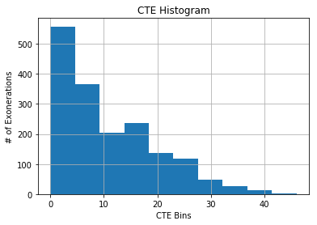

```python
plot_hist(train.CTE, 'CTE Histogram', 'CTE Bins', '# of Exonerations')
```

#### Observations:

#### Response variable is not normally distributed and is highly skewed. Hence it could be difficult to predict values in higher bins if enough observations are not available for training

### Log transforming response to check if distribution improves

```python
train['log_CTE'] = np.log1p(train.CTE)
```

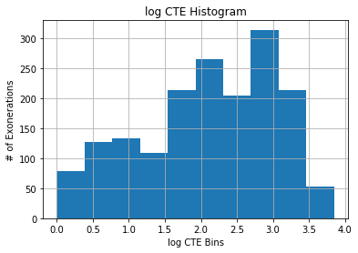

```python
plot_hist(train.log_CTE, 'log CTE Histogram', 'log CTE Bins', '# of Exonerations')
```

#### log transformed distribution is more normal than previous distribution, though there is some skewness observed. So regression on original and transformed response variables can be built to look for best fit.

### Response statistics

```python
print_statistics(train.CTE)
```

```
mean: 10.762573099415205
sd: 9.021384278468727
max: 46
min: 0
median: 8.0
mode: 2
```

### Log response statistics

```python
print_statistics(np.log1p(train.CTE))
```

```
mean: 2.1088003907742805
sd: 0.922729247389755
max: 3.8501476017100584
min: 0.0
median: 2.1972245773362196
mode: 1.0986122886681098
```

#### Observations:

#### Clearly log response statistics exhibit a better distribution with median and mean being very close. And they are also very close to mid point of min and max

# Analysis of regressors

## Age

### # of Exonerations distribution

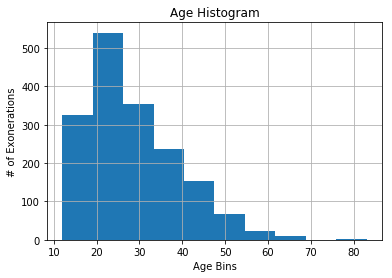

```python
plot_hist(train.Age, 'Age Histogram', 'Age Bins', '# of Exonerations')
```

### Variable statistics

```python
print_statistics(train.Age)
```

```
mean: 28.84327485380117
sd: 10.294038611295742
max: 83
min: 12
median: 26.0
mode: 19
```

### Age vs CTE

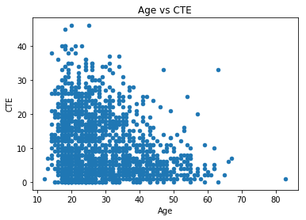

```python
plot_scatter(train, 'Age', 'CTE', 'Age vs CTE', 'Age', 'CTE')
```

#### Observations:

#### No clear relationship observed. Very slight exponential relationship can be drawn from this plot.

### Age vs log CTE

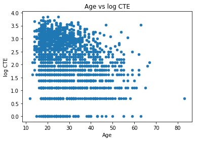

```python
plot_scatter(train, 'Age', 'log_CTE', 'Age vs log CTE', 'Age', 'log CTE')
```

#### Observations: No improvement

### Log Age vs CTE

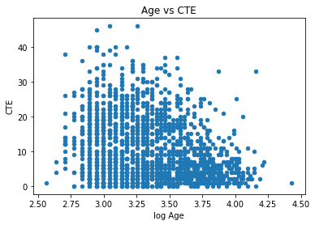

```python
train_age = train
train['log_Age'] = np.log1p(train.Age)

plot_scatter(train_age, 'log_Age', 'CTE', 'Age vs CTE', 'log Age', 'CTE')
```

#### Observations: Even transformation on Age is not helpful

### Age vs CTE reciprocal

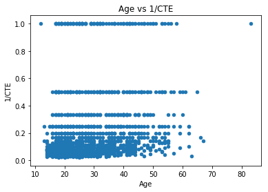

```python
train_trans = train
train['CTE_reciprocal'] = 1 / train.CTE

plot_scatter(train_trans, 'Age', 'CTE_reciprocal', 'Age vs 1/CTE', 'Age', '1/CTE')
```

#### Observations: Not useful

### Conclusion: Age will be fit in a model to identify its relationship with CTE. From EDA there is no strong relationship.

## Race

### Counting exonerations per Race

```python
race = train.groupby(['Race'])['CTE'].count().reset_index(name='exoneration_count')
race.head()
```

|  | Race | exoneration_count |
| --- | --- | --- |
| 0 | Asian | 20 |
| 1 | Black | 782 |
| 2 | Hispanic | 214 |
| 3 | Native American | 14 |
| 4 | Other | 10 |

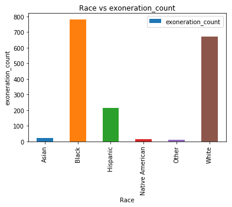

```python
plot_bar(race, 'Race', 'exoneration_count', 'Race vs exoneration_count', 'Race', 'exoneration_count')
```

#### Observations: Only 3 levels seems to be significant and hence rest can be rolled into significant categories. But overall level count is also lower levels can be left as it is.

### Measuring average CTE per Race

```python
race = train.groupby(['Race'])['CTE'].mean().reset_index(name='CTE_mean')
race.head()
```

|  | Race | CTE_mean |
| --- | --- | --- |
| 0 | Asian | 6.600000 |
| 1 | Black | 12.698210 |
| 2 | Hispanic | 8.542056 |
| 3 | Native American | 15.714286 |
| 4 | Other | 4.500000 |

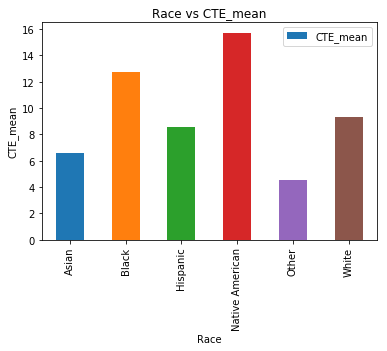

```python
plot_bar(race, 'Race', 'CTE_mean', 'Race vs CTE_mean', 'Race', 'CTE_mean')
```

#### Observations: There is no concentration of CTE mean for any single level. So Race could be a significant variable.

## Sex

### Counting exonerations per Sex

```python
sex = train.groupby(['Sex'])['CTE'].count().reset_index(name='CTE_count')
sex.head()
```

|  | Sex | CTE_count |
| --- | --- | --- |
| 0 | Female | 147 |
| 1 | Male | 1563 |

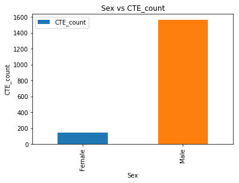

```python
plot_bar(sex, 'Sex', 'CTE_count', 'Sex vs CTE_count', 'Sex', 'CTE_count')
```

#### Observations: Significant class imbalance within Sex regressor

### Measuring CTE_mean per Sex

```python
sex = train.groupby(['Sex'])['CTE'].mean().reset_index(name='CTE_mean')
sex.head()
```

|  | Sex | CTE_mean |
| --- | --- | --- |
| 0 | Female | 6.680272 |
| 1 | Male | 11.146513 |

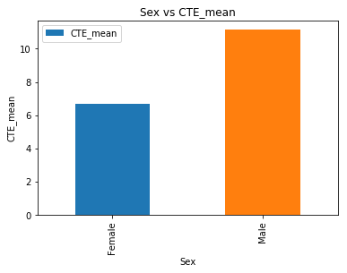

```python
plot_bar(sex, 'Sex', 'CTE_mean', 'Sex vs CTE_mean', 'Sex', 'CTE_mean')
```

#### Observations: 'Female' one-hot-encoded level might not be as significant as expected from its CTE_count as the CTE_mean is not very low

## State

### Counting CTE per State

```python
state = train.groupby(['State'])['CTE'].count().reset_index(name='CTE_count')
state.head()
```

|  | State | CTE_count |
| --- | --- | --- |
| 0 | Alabama | 17 |
| 1 | Alaska | 6 |
| 2 | Arizona | 14 |
| 3 | Arkansas | 4 |
| 4 | California | 153 |

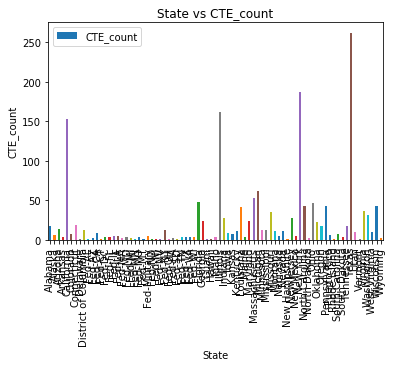

```python
plot_bar(state, 'State', 'CTE_count', 'State vs CTE_count', 'State', 'CTE_count')
```

#### Observations: Multiple levels can be rolled into other significant levels

### Measuring CTE_mean per State

```python
state = train.groupby(['State'])['CTE'].mean().reset_index(name='CTE_mean')
state.head()
```

|  | State | CTE_mean |
| --- | --- | --- |
| 0 | Alabama | 8.176471 |
| 1 | Alaska | 12.333333 |
| 2 | Arizona | 8.142857 |
| 3 | Arkansas | 8.750000 |
| 4 | California | 10.594771 |

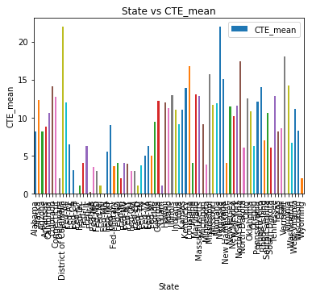

```python
plot_bar(state, 'State', 'CTE_mean', 'State vs CTE_mean', 'State', 'CTE_mean')
```

### CTE_mean per State distribution

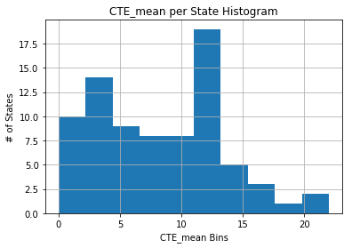

```python
plot_hist(state.CTE_mean, 'CTE_mean per State Histogram', 'CTE_mean Bins', '# of States')
```

```python
print_statistics(state.CTE_mean)
```

```
mean: 8.454420886450453
sd: 5.132160165739004
max: 22.0
min: 0.0
median: 8.6
mode: 4.0
```

#### Observations: Though skewness is observed in histogram, the statistics indicate a good distribution. Regression on one-hot-encoded values could be significant

## Worst.Crime.Display

### Counting CTE per Worst.Crime.Display

```python
crime = train.groupby(['Worst.Crime.Display'])['CTE'].count().reset_index(name='CTE_count')
crime.head()
```

|  | Worst.Crime.Display | CTE_count |
| --- | --- | --- |
| 0 | Accessory to Murder | 1 |
| 1 | Arson | 16 |
| 2 | Assault | 64 |
| 3 | Attempt, Violent | 3 |
| 4 | Attempted Murder | 39 |

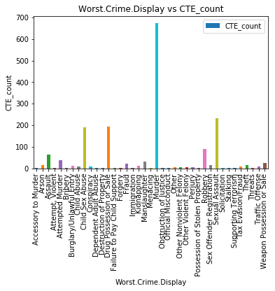

```python
plot_bar(crime, 'Worst.Crime.Display', 'CTE_count', 'Worst.Crime.Display vs CTE_count', 'Worst.Crime.Display', 'CTE_count')
```

#### Observations: Multiple levels have very less proportion of observations. 'Murder' level seems to be very frequent.

### Measuring CTE_mean per Worst.Crime.Display

```python
crime = train.groupby(['Worst.Crime.Display'])['CTE'].mean().reset_index(name='CTE_mean')
crime.head()
```

|  | Worst.Crime.Display | CTE_mean |
| --- | --- | --- |
| 0 | Accessory to Murder | 1.000000 |
| 1 | Arson | 5.187500 |
| 2 | Assault | 7.906250 |
| 3 | Attempt, Violent | 10.666667 |
| 4 | Attempted Murder | 8.333333 |

```python
crime.columns = ['Crime', 'CTE_mean']
```

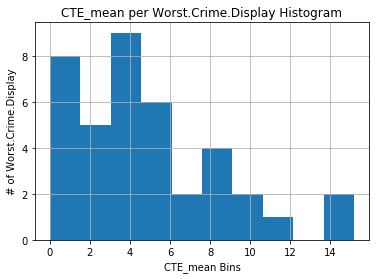

```python
plot_hist(crime.CTE_mean, 'CTE_mean per Worst.Crime.Display Histogram', 'CTE_mean Bins', '# of Worst.Crime.Display')
```

```python
print_statistics(crime.CTE_mean)
```

```
mean: 4.995952630945546
sd: 3.642465277545065
max: 15.189655172413794
min: 0.0
median: 4.142857142857143
mode: 1.0
```

#### Observations: Clear skeweness observed. Some levels have more concentration of CTE_mean. Multiple levels can be ignores to be rolled into other levels.